# Depuración datos

Juan Baeza Ruiz-Henestrosa

2024-04-06

## Lectura de los datos

Cargamos el archivo de datos que hemos creado anteriormente con `1_generacion_muestra.R` para generar los puntos alteatorios en fechas aleatorias y con `2_asignacion_variables_a_localizaciones.R` para asociar a cada punto el valor correspondiente de cada variable:

```r
load("salidas_intermedias/dataset_completo2024-03-27.RData")

datos = dataset |>
  select(-c(YEAR,MM,DD))
```

Se trata de un objeto de clase `sf` y `data.frame`:

```r
str(datos)
```

```
## Classes 'sf' and 'data.frame':   22610 obs. of  26 variables:
##  $ fire           : num  1 1 1 1 1 1 1 1 1 1 ...
##  $ date           : Date, format: "2000-06-16" "2000-06-16" ...
##  $ T2M            : num  22.1 22.1 22.1 22.1 22.1 ...
##  $ GWETTOP        : num  0.52 0.52 0.52 0.52 0.52 0.52 0.52 0.52 0.52 0.52 ...
##  $ RH2M           : num  66.6 66.6 66.6 66.6 66.6 ...
##  $ WD10M          : num  98.3 98.3 98.3 98.3 98.3 ...
##  $ WS10M          : num  10.8 10.8 10.8 10.8 10.8 ...
##  $ PRECTOTCORR    : num  0 0 0 0 0 0 0 0 0 0 ...
##  $ elevacion      : num  151.8 18.1 212.6 181.2 224.7 ...
##  $ pendiente      : num  24.6 15.1 18.4 28 13.3 ...
##  $ orientacion    : num  174 238 243 167 230 ...
##  $ curvatura      : num  -0.0354 -0.06778 0.02992 0.00641 0.06084 ...
##  $ dist_carretera : num  580.6 26.9 583.5 612.7 722.8 ...
##  $ dist_poblacion : num  474 578 877 541 840 ...
##  $ dist_electr    : num  4157 4619 4448 4173 4284 ...
##  $ dist_ferocarril: num  33946 34489 34158 33947 33992 ...
##  $ dist_camino    : num  163 313 590 218 508 ...
##  $ dist_sendero   : num  7434 7218 7034 7391 7171 ...
##  $ enp            : num  0 0 0 0 0 0 0 0 0 0 ...
##  $ cod_municipio  : chr  "11007" "11007" "11007" "11007" ...
##  $ municipio      : chr  "Barbate" "Barbate" "Barbate" "Barbate" ...
##  $ poblacion      : int  22020 22020 22020 22020 22020 22020 22020 22020 22020 22020 ...
##  $ uso_suelo      : Factor w/ 42 levels "111","112","121",..: 18 18 28 28 28 28 28 18 28 28 ...
##  $ dist_rios      : num  5485 5173 5123 5452 5277 ...
##  $ NDVI           : num  NA NA NA NA NA NA NA NA NA NA ...
##  $ geometry       :sfc_POINT of length 22610; first list element:  'XY' num  243183 4004959
##  - attr(*, "sf_column")= chr "geometry"
##  - attr(*, "agr")= Factor w/ 3 levels "constant","aggregate",..: NA NA NA NA NA NA NA NA NA NA ...
##   ..- attr(*, "names")= chr [1:25] "fire" "date" "T2M" "GWETTOP" ...
```

Variables:

```
- fire: Variable respuesta con dos clases. Indica si en esa observación hay un incendio (1) o no (0).

- date: Fecha de la observación

- T2M: Temperatura del a 2m. The average air (dry bulb) temperature at 2 meters above the surface of the earth.

- GWETTOP: Surface Soil Wetness. The percent of soil moisture a value of 0 indicates a completely water-free soil and a value of 1 indicates a completely saturated soil; where surface is the layer from the surface 0 cm to 5 cm below grade.

- RH2M : Humedad relativa a 2m.The ratio of actual partial pressure of water vapor to the partial pressure at saturation, expressed in percent.

- WD10M: Wind Direction at 10m. The average of the wind direction at 10 meters above the surface of the earth (º).

- WS10M: Wind Speed at 10m. The average of wind speed at 10 meters above the surface of the earth (m/s).

- PRECTOTCORR: Precipitation Corrected.  The bias corrected average of total precipitation at the surface of the earth in water mass (includes water content in snow) (mm/day).


- elevacion: Elevación sobre el nivel del mar (m).

- pendiente: Pendiente del terreno (º).

- orientacion: Orientación de la pendiente descendiente medida en sentido de las agujas del reloj (º). Las áreas planas que no tienen dirección de pendiente descendente tienen un valor de -1.
```

https://desktop.arcgis.com/es/arcmap/latest/tools/spatial-analyst-toolbox/how-aspect-works.htm

```
- curvatura: Curvatura de la superfie ()
```

https://desktop.arcgis.com/es/arcmap/latest/manage-data/raster-and-images/curvature-function.htm

```
- dist_carretera: Distancia a la carretera más cercana (m).

- dist_poblacion: Distancia a la población más cercana (m).

- dist_electr: Distancia a la línea electrica más cercana (m).

- dist_ferocarril: Distancia a la vía de ferrocarril más cercana (m).

- dist_camino: Distancia al camino o a la vía pecuaria más cercana (m).

- dist_sendero: Distancia a la vía verde, al carril bici o al sendero más cercano (m).

- enp: Espacio Natural Protegido. Su valor es 1 si la observación se encuentra dentro de un espacio natural protegido o 0 en caso contrario.

- cod_municipio: Código del municipio en el que está la observación.

- municipio: Nombre del municipio en en el que está la observación.

- poblacion: Número de habitantes del municipio en el que se encuentra la observación en ese año.

- uso_suelo: Clasificación del uso del suelo.

- dist_rios: Distancia al río más próximo (m).

- NDVI: Índice de vegetación de diferencia normalizada.

- geometry: Geometría de la simple feature. En este caso, coordenadas del punto.
```

## Codificación variables categóricas

```r
summary(datos)
```

```
##       fire             date                 T2M           GWETTOP
##  Min.   :0.0000   Min.   :2000-01-01   Min.   :-5.49   Min.   :0.0900
##  1st Qu.:0.0000   1st Qu.:2005-07-09   1st Qu.:14.48   1st Qu.:0.2400
##  Median :0.0000   Median :2011-11-22   Median :23.14   Median :0.4000
##  Mean   :0.4994   Mean   :2011-10-04   Mean   :20.90   Mean   :0.3964
##  3rd Qu.:1.0000   3rd Qu.:2017-08-23   3rd Qu.:26.80   3rd Qu.:0.5300
##  Max.   :1.0000   Max.   :2022-12-31   Max.   :35.87   Max.   :0.9700
##
##       RH2M           WD10M            WS10M        PRECTOTCORR
##  Min.   : 9.23   Min.   : 15.42   Min.   : 0.97   Min.   : 0.0000
##  1st Qu.:38.20   1st Qu.:138.90   1st Qu.: 2.68   1st Qu.: 0.0000
##  Median :53.38   Median :207.13   Median : 3.43   Median : 0.0000
##  Mean   :54.22   Mean   :199.78   Mean   : 3.79   Mean   : 0.6429
##  3rd Qu.:70.09   3rd Qu.:262.24   3rd Qu.: 4.54   3rd Qu.: 0.0300
##  Max.   :98.31   Max.   :345.09   Max.   :14.56   Max.   :59.9000
##
##    elevacion          pendiente       orientacion      curvatura
##  Min.   :  -0.005   Min.   : 0.000   Min.   : -1.0   Min.   :-0.34617
##  1st Qu.: 169.464   1st Qu.: 3.431   1st Qu.:102.2   1st Qu.:-0.01986
##  Median : 423.985   Median : 8.394   Median :182.1   Median :-0.00007
##  Mean   : 495.024   Mean   :12.298   Mean   :181.3   Mean   : 0.00554
##  3rd Qu.: 709.507   3rd Qu.:17.835   3rd Qu.:262.1   3rd Qu.: 0.02543
##  Max.   :3177.482   Max.   :83.012   Max.   :360.0   Max.   : 0.41995
##                     NA's   :33       NA's   :45      NA's   :33
##  dist_carretera      dist_poblacion    dist_electr       dist_ferocarril
##  Min.   :    0.079   Min.   :   0.0   Min.   :    0.02   Min.   :    0.35
##  1st Qu.:  507.160   1st Qu.: 372.7   1st Qu.: 1244.33   1st Qu.: 5191.09
##  Median : 1198.461   Median : 707.1   Median : 3478.69   Median :11783.67
##  Mean   : 1813.456   Mean   : 905.1   Mean   : 5235.90   Mean   :15342.93
##  3rd Qu.: 2440.963   3rd Qu.:1181.5   3rd Qu.: 7231.06   3rd Qu.:21487.56
##  Max.   :18417.365   Max.   :8109.4   Max.   :49601.00   Max.   :86148.53
##
##   dist_camino        dist_sendero            enp         cod_municipio
##  Min.   :   0.003   Min.   :    0.193   Min.   :0.0000   Length:22610
##  1st Qu.: 236.977   1st Qu.: 1751.180   1st Qu.:0.0000   Class :character
##  Median : 544.272   Median : 4293.978   Median :0.0000   Mode  :character
##  Mean   : 761.525   Mean   : 5590.348   Mean   :0.1995
##  3rd Qu.:1061.837   3rd Qu.: 8226.423   3rd Qu.:0.0000
##  Max.   :7191.301   Max.   :24895.911   Max.   :1.0000
##
##   municipio           poblacion        uso_suelo      dist_rios
##  Length:22610       Min.   :    50   323    :5034   Min.   :    0.1
##  Class :character   1st Qu.:  2265   223    :2365   1st Qu.: 2165.1
##  Mode  :character   Median :  4867   244    :2156   Median : 5317.1
##                     Mean   : 22344   211    :1803   Mean   : 6828.3
##                     3rd Qu.: 16759   324    :1700   3rd Qu.:10319.8
##                     Max.   :704414   (Other):9540   Max.   :37805.5
##                     NA's   :76       NA's   :  12
##       NDVI                 geometry
##  Min.   :0.0000   POINT        :22610
##  1st Qu.:0.3299   epsg:NA      :    0
##  Median :0.4179   +proj=utm ...:    0
##  Mean   :0.4382
##  3rd Qu.:0.5337
##  Max.   :0.9832
##  NA's   :1863
```

Indicamos las variables que son factores:

```r
datos <- datos |>
  mutate(fire = as.factor(fire),
         enp = as.factor(enp),
         uso_suelo = as.factor(uso_suelo))
```

Es habitual trabajar con la orientación recodificada indicando cada uno de los 8 puntos cardinales o si no hay pendiente descendente.

```r
datos = datos |>
  mutate(orientacion = cut(orientacion,
                           breaks = c(-Inf,-1,22.5,67.5,112.5,157.5,202.5,247.5,292.5,337.5,360),
                           labels = c("Plano","N","NE","E","SE","S","SW","W","NW","N")))
```

## Valores perdidos

```r
summary(datos)
```

```
##  fire           date                 T2M           GWETTOP
##  0:11318   Min.   :2000-01-01   Min.   :-5.49   Min.   :0.0900
##  1:11292   1st Qu.:2005-07-09   1st Qu.:14.48   1st Qu.:0.2400
##            Median :2011-11-22   Median :23.14   Median :0.4000
##            Mean   :2011-10-04   Mean   :20.90   Mean   :0.3964
##            3rd Qu.:2017-08-23   3rd Qu.:26.80   3rd Qu.:0.5300
##            Max.   :2022-12-31   Max.   :35.87   Max.   :0.9700
##
##       RH2M           WD10M            WS10M        PRECTOTCORR
##  Min.   : 9.23   Min.   : 15.42   Min.   : 0.97   Min.   : 0.0000
##  1st Qu.:38.20   1st Qu.:138.90   1st Qu.: 2.68   1st Qu.: 0.0000
##  Median :53.38   Median :207.13   Median : 3.43   Median : 0.0000
##  Mean   :54.22   Mean   :199.78   Mean   : 3.79   Mean   : 0.6429
##  3rd Qu.:70.09   3rd Qu.:262.24   3rd Qu.: 4.54   3rd Qu.: 0.0300
##  Max.   :98.31   Max.   :345.09   Max.   :14.56   Max.   :59.9000
##
##    elevacion          pendiente       orientacion     curvatura
##  Min.   :  -0.005   Min.   : 0.000   S      :3481   Min.   :-0.34617
##  1st Qu.: 169.464   1st Qu.: 3.431   SW     :3159   1st Qu.:-0.01986
##  Median : 423.985   Median : 8.394   SE     :3146   Median :-0.00007
##  Mean   : 495.024   Mean   :12.298   W      :2644   Mean   : 0.00554
##  3rd Qu.: 709.507   3rd Qu.:17.835   NW     :2600   3rd Qu.: 0.02543
##  Max.   :3177.482   Max.   :83.012   (Other):7535   Max.   : 0.41995
##                     NA's   :33       NA's   :  45   NA's   :33
##  dist_carretera      dist_poblacion    dist_electr       dist_ferocarril
##  Min.   :    0.079   Min.   :   0.0   Min.   :    0.02   Min.   :    0.35
##  1st Qu.:  507.160   1st Qu.: 372.7   1st Qu.: 1244.33   1st Qu.: 5191.09
##  Median : 1198.461   Median : 707.1   Median : 3478.69   Median :11783.67
##  Mean   : 1813.456   Mean   : 905.1   Mean   : 5235.90   Mean   :15342.93
##  3rd Qu.: 2440.963   3rd Qu.:1181.5   3rd Qu.: 7231.06   3rd Qu.:21487.56
##  Max.   :18417.365   Max.   :8109.4   Max.   :49601.00   Max.   :86148.53
##
##   dist_camino        dist_sendero       enp       cod_municipio
##  Min.   :   0.003   Min.   :    0.193   0:18100   Length:22610
##  1st Qu.: 236.977   1st Qu.: 1751.180   1: 4510   Class :character
##  Median : 544.272   Median : 4293.978             Mode  :character
##  Mean   : 761.525   Mean   : 5590.348
##  3rd Qu.:1061.837   3rd Qu.: 8226.423
##  Max.   :7191.301   Max.   :24895.911
##
##   municipio           poblacion        uso_suelo      dist_rios
##  Length:22610       Min.   :    50   323    :5034   Min.   :    0.1
##  Class :character   1st Qu.:  2265   223    :2365   1st Qu.: 2165.1
##  Mode  :character   Median :  4867   244    :2156   Median : 5317.1
##                     Mean   : 22344   211    :1803   Mean   : 6828.3
##                     3rd Qu.: 16759   324    :1700   3rd Qu.:10319.8
##                     Max.   :704414   (Other):9540   Max.   :37805.5
##                     NA's   :76       NA's   :  12
##       NDVI                 geometry
##  Min.   :0.0000   POINT        :22610
##  1st Qu.:0.3299   epsg:NA      :    0
##  Median :0.4179   +proj=utm ...:    0
##  Mean   :0.4382
##  3rd Qu.:0.5337
##  Max.   :0.9832
##  NA's   :1863
```

Los valores perdidos de pendiente, orientación y curvatura se encuentran todos en los límites de Andalucía, como se muestra en el siguiente gráfico. Esto nos indica que la causa de que estos valores no estén disponibles es precisamente la discrepancia entre los distintos sistemas de referencia o entre los distintos polígonos utilizados para delimitar el territorio

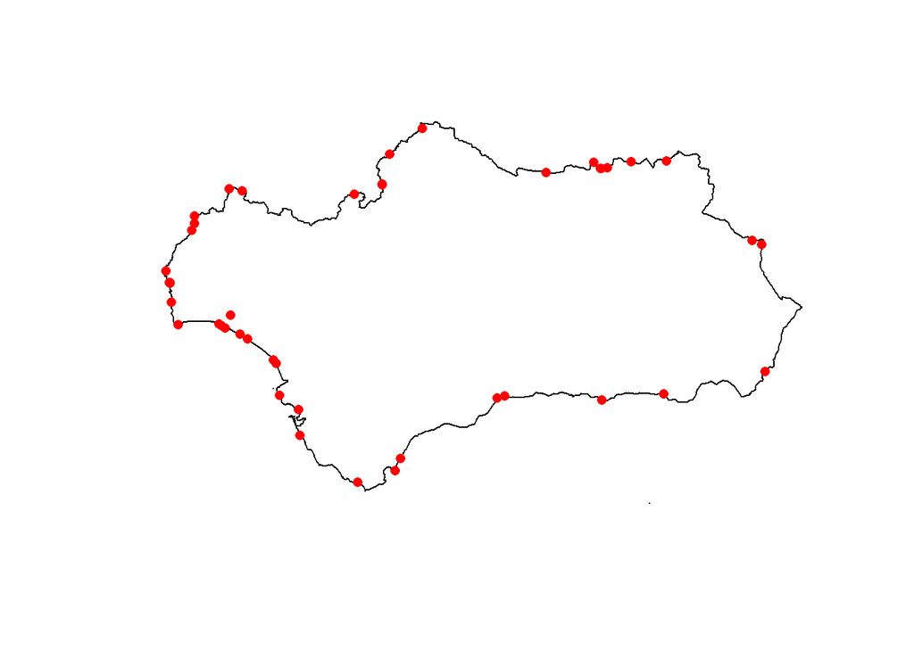

```r
Andalucia <- esp_get_ccaa(ccaa = "Andalucía")
andalucia_proj <- st_transform(Andalucia,st_crs(dataset))


plot(st_geometry(andalucia_proj),reset=F)
datos |>
  filter(is.na(pendiente)| is.na(orientacion) | is.na(curvatura)) |>
  st_geometry() |>
  plot(pch=16,col="red",add=T)
```

```r
datos |>
  st_drop_geometry() |>
  filter(is.na(pendiente)| is.na(orientacion) | is.na(curvatura)) |>
  count() #53 observaciones NA
```

```
##    n
## 1 53
```

Al ser un número reducido de observaciones (53), puede ser razonable simplemente eliminarlas.

```r
datos = datos |>
  filter(!(is.na(pendiente)| is.na(orientacion) | is.na(curvatura)))

summary(datos)
```

```
##  fire           date                 T2M           GWETTOP
##  0:11287   Min.   :2000-01-01   Min.   :-5.49   Min.   :0.0900
##  1:11270   1st Qu.:2005-07-09   1st Qu.:14.48   1st Qu.:0.2400
##            Median :2011-11-23   Median :23.14   Median :0.4000
##            Mean   :2011-10-04   Mean   :20.90   Mean   :0.3965
##            3rd Qu.:2017-08-23   3rd Qu.:26.79   3rd Qu.:0.5300
##            Max.   :2022-12-31   Max.   :35.87   Max.   :0.9700
##
##       RH2M           WD10M            WS10M         PRECTOTCORR
##  Min.   : 9.23   Min.   : 15.42   Min.   : 0.970   Min.   : 0.0000
##  1st Qu.:38.16   1st Qu.:138.89   1st Qu.: 2.680   1st Qu.: 0.0000
##  Median :53.38   Median :207.13   Median : 3.430   Median : 0.0000
##  Mean   :54.21   Mean   :199.77   Mean   : 3.789   Mean   : 0.6431
##  3rd Qu.:70.09   3rd Qu.:262.22   3rd Qu.: 4.540   3rd Qu.: 0.0300
##  Max.   :98.31   Max.   :345.09   Max.   :14.560   Max.   :59.9000
##
##    elevacion          pendiente       orientacion     curvatura
##  Min.   :  -0.005   Min.   : 0.000   S      :3478   Min.   :-0.346170
##  1st Qu.: 170.325   1st Qu.: 3.433   SW     :3156   1st Qu.:-0.019880
##  Median : 424.772   Median : 8.395   SE     :3146   Median :-0.000080
##  Mean   : 495.573   Mean   :12.299   W      :2644   Mean   : 0.005517
##  3rd Qu.: 709.686   3rd Qu.:17.835   NW     :2599   3rd Qu.: 0.025420
##  Max.   :3177.482   Max.   :83.012   E      :2541   Max.   : 0.419950
##                                      (Other):4993
##  dist_carretera      dist_poblacion    dist_electr       dist_ferocarril
##  Min.   :    0.079   Min.   :   0.0   Min.   :    0.02   Min.   :    0.35
##  1st Qu.:  507.602   1st Qu.: 373.4   1st Qu.: 1242.28   1st Qu.: 5189.88
##  Median : 1198.246   Median : 707.5   Median : 3472.86   Median :11773.33
##  Mean   : 1810.397   Mean   : 904.5   Mean   : 5218.43   Mean   :15325.80
##  3rd Qu.: 2436.966   3rd Qu.:1180.7   3rd Qu.: 7215.52   3rd Qu.:21453.08
##  Max.   :18417.365   Max.   :8109.4   Max.   :49601.00   Max.   :86148.53
##
##   dist_camino        dist_sendero       enp       cod_municipio
##  Min.   :   0.003   Min.   :    0.193   0:18058   Length:22557
##  1st Qu.: 236.819   1st Qu.: 1758.391   1: 4499   Class :character
##  Median : 543.809   Median : 4296.909             Mode  :character
##  Mean   : 760.655   Mean   : 5595.094
##  3rd Qu.:1060.641   3rd Qu.: 8228.636
##  Max.   :7191.301   Max.   :24895.911
##
##   municipio           poblacion        uso_suelo      dist_rios
##  Length:22557       Min.   :    50   323    :5024   Min.   :    0.1
##  Class :character   1st Qu.:  2267   223    :2365   1st Qu.: 2167.4
##  Mode  :character   Median :  4868   244    :2148   Median : 5322.8
##                     Mean   : 22301   211    :1799   Mean   : 6829.1
##                     3rd Qu.: 16759   324    :1698   3rd Qu.:10321.0
##                     Max.   :704414   (Other):9520   Max.   :37805.5
##                     NA's   :75       NA's   :   3
##       NDVI                 geometry
##  Min.   :0.0000   POINT        :22557
##  1st Qu.:0.3300   epsg:NA      :    0
##  Median :0.4180   +proj=utm ...:    0
##  Mean   :0.4383
##  3rd Qu.:0.5337
##  Max.   :0.9832
##  NA's   :1849
```

### Población:

En el caso de la población, es debido a que el dato de población para esos municipios concretos en esos años concretos no estaba disponible en la base de datos del INE.

```r
datos |>
  st_drop_geometry() |>
  filter(is.na(poblacion)) |>
  mutate(Año = year(date)) |>
  select(Año,municipio,cod_municipio)
```

```
##     Año                   municipio cod_municipio
## 1  2000                      Fornes         18077
## 2  2001                       Játar         18106
## 3  2001           Arroyo del Ojanco         23905
## 4  2002                   Balanegra         04904
## 5  2002           La Zarza-Perrunal         21902
## 6  2002    San Martín del Tesorillo         11903
## 7  2003                     Serrato         29904
## 8  2003          El Palmar de Troya         41904
## 9  2003 Villanueva de la Concepción         29902
## 10 2004               La Guijarrosa         14902
## 11 2004            Torrenueva Costa         18916
## 12 2004    Domingo Pérez de Granada         18915
## 13 2005                  Montecorto         29903
## 14 2005                  Montecorto         29903
```

[output cut: 61 more lines]

Ejemplo :

```r
pob = read_csv2("D:/usuario/Documents/Universidad/5º/TFG - organizado/data_raw/antropologicas/Población/poblacion_municipios.txt")[,c(1:5)]
```

```
## ℹ Using "','" as decimal and "'.'" as grouping mark. Use `read_delim()` for more control.
```

```
## ──────────────────────────────────────────────────────── Delimiter: ";" chr
## (4): Lugar de residencia, CODIGO_INE3, Medida, Valor dbl (1): Anual lgl (1):
## ...6
```

```r
pob |> filter(CODIGO_INE3 == "18077")
```

```
## # A tibble: 25 × 5
##    `Lugar de residencia` CODIGO_INE3 Anual Medida              Valor
##    <chr>                 <chr>       <dbl> <chr>               <chr>
##  1 Fornes                18077        2022 Población municipal 519
##  2 Fornes                18077        2021 Población municipal 534
##  3 Fornes                18077        2020 Población municipal 556
##  4 Fornes                18077        2019 Población municipal 555
##  5 Fornes                18077        2018 Población municipal -
##  6 Fornes                18077        2017 Población municipal -
##  7 Fornes                18077        2016 Población municipal -
##  8 Fornes                18077        2015 Población municipal -
##  9 Fornes                18077        2014 Población municipal -
## 10 Fornes                18077        2013 Población municipal -
## # ℹ 15 more rows
```

Se opta en un primer momento por eliminar dichas observaciones.

```r
datos %<>% filter(!is.na(poblacion))
```

### Uso de suelo

Se trata de observaciones que se encuentran también en los límites de Andalucía, en este caso en la costa. Esto nos puede indicar que la causa de que este valor no esté disponible es la misma que anteriormente con las variables topográficas. Dado que el Sistema de Referencia de Coordenadas no se ha modificado, probablemente sea debido a pequeñas discrepancias entre los polígonos utilizados. Ante esto y teniendo en cuenta que son solo 3 observaciones, las eliminamos directamente.

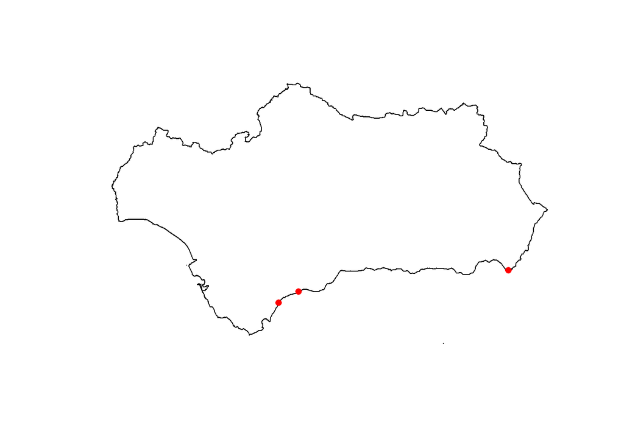

```r
plot(st_geometry(andalucia_proj),reset=F)
datos |> filter(is.na(uso_suelo)) |> st_geometry() |> plot(pch=16,col="red",add=T)
```

```r
datos = datos |>
  filter(!is.na(uso_suelo))
```

### NDVI

El caso de los valores perdidos en NDVI es particular, ya que se debe a que no están disponibles los datos del NDVI de esos meses.

```r
NDVI_mes = datos |>
  st_drop_geometry() |>
  mutate(mes = month(date),
         año = year(date)) |>
  group_by(año,mes) |>
  summarise(NDVI_mes = mean(na.omit(NDVI))) |>
  ungroup() |>
  mutate(date = dmy(paste(01,mes,año,sep="/")))
```

[output not shown]

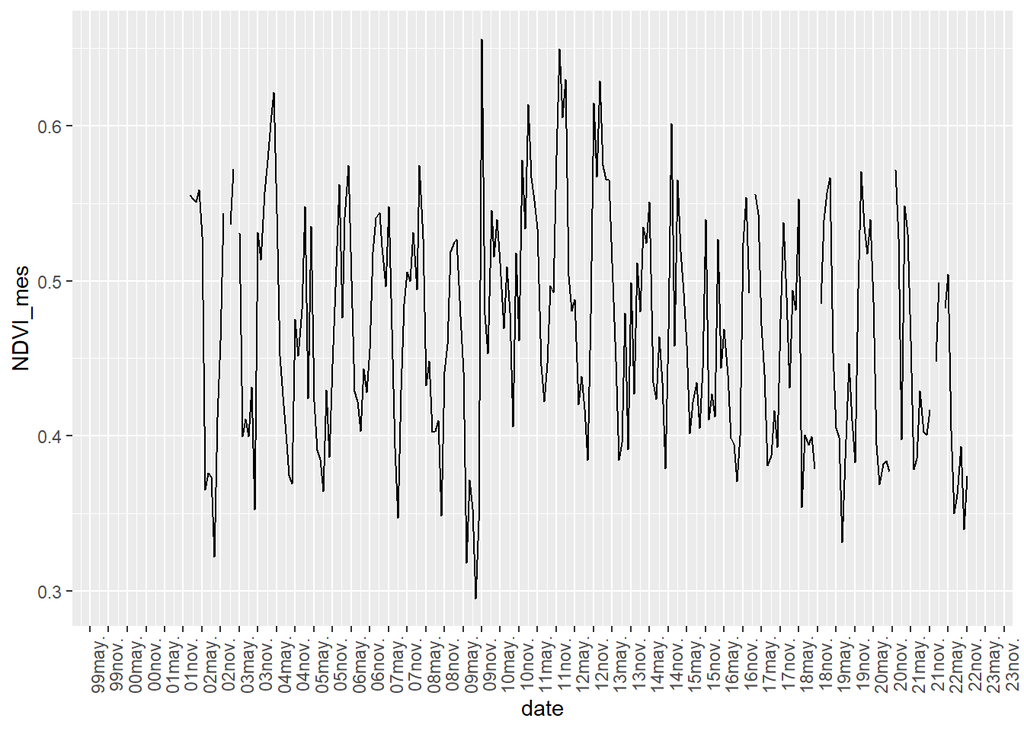

```r
NDVI_mes |>
  ggplot(aes(x=date,y=NDVI_mes)) +
  geom_line()+
  scale_x_date(date_breaks = "6 month",date_labels = "%y%b")+
  theme(axis.text.x = element_text(angle = 90))
```

La cuestión principal es qué hacer con los años 2000 y 2001, ya que los demás, al ser meses aislados, es razoble imputarlos. Las opciones son:

[output not shown]

En este caso, se opta por la primera opción y se reduce el marco temporal del estudio a los años 2002 a 2022.

```r
datos %<>% filter(!year(date) %in% 2000:2001)
```

Se imputan las observaciones faltantes de los demás meses, tomando utilizando una técnica similar a la imputación Hot Deck. Para cada mes para el que no esté disponible el NDVI, se le asigna el valor correspondiente al mismo mes del año anterior si está disponible y si no el del año posterior.

```r
# La siguiente función lee el archivo con el NDVI corresponfiente a un mes y a un año dados (si está disponible)

read_NDVI = function(MM,YYYY) {
  MM = str_pad(as.character(MM),2,"left",pad = "0")
  YY = substr(as.character(YYYY),3,4)
  if (as.numeric(YY)<=06) {
    ruta <- paste0("data_raw/vegetacion/",YYYY,"TERMODMEDMNDVI/InfGeografica/InfRaster/TIFF/TERMOD_",YY,MM,"01_h17v05_medmndvi.tif")
  } else if (as.numeric(YY)<=11) {
    ruta <- paste0("data_raw/vegetacion/",YYYY,"TERMODMEDMNDVI/InfGeografica/InfRaster/TIF/TERMOD_",YY,MM,"01_h17v05_medmndvi.tif")
  } else if (as.numeric(YY)<=21){
    ruta <- paste0("data_raw/vegetacion/",YYYY,"TERMODMEDMNDVI/InfGeografica/InfRaster/TIFF/termod_",YY,MM,"01_h17v05_medmndvi.tif")
  }else {
    ruta <- paste0("data_raw/vegetacion/",YYYY,"TERMODMEDMNDVI/InfGeografica/InfRaster/COG/termod_",YY,MM,"01_h17v05_medmndvi_COG.tif")
  }

  if (file.exists(ruta)) {
    NDVI = rast(ruta)
  } else
    NDVI = NA
  return(NDVI)
}

# Los meses para los cuales no está disponible el NDVI:
year_month_missing_NDVI = c(
"2003-01",
"2003-04",
"2017-02",
"2018-11",
"2020-11",
"2021-12",
"2022-03",
"2022-12")

# Para cada observación para la que no está disponible el NDVI (porque la información de ese mes no está disponible), se obtiene el correspondiente al mismo mes del año anterior, si este está disponible, si no, el del año posterior:

missing_NDVI = datos |>
  filter(is.na(NDVI)) |>
  mutate(year = year(date),month = month(date)) |>
  group_by(year,month) |>
  filter(paste(year,str_pad(as.character(month),2,"left",pad = "0"),sep="-") %in%   year_month_missing_NDVI) |>  # Se filtra porque también hay observaciones que tienen NA en el NDVI no porque no exista el archivo, si no lo mismo que en ocasiones anteriores, porques discrepancias entre los límites de los polígonos
  nest() |>
  mutate(NDVI_rast = map2(month,year-1,read_NDVI), # Se lee primero el del año anterior
         NDVI_rast = ifelse(is.na(unlist(NDVI_rast)),map2(month,year+1,read_NDVI),NDVI_rast), # Si no está disponible, se toma el del año posterior
         NDVI_nuevo = map2(NDVI_rast,data,~terra::extract(.x,.y)[,2])) |>
  select(-NDVI_rast) |>
  unnest(c(data,NDVI_nuevo)) |>
  mutate(NDVI = NDVI_nuevo,.keep="unused")
ind_modificados = is.na(datos$NDVI) & (paste(year(datos$date),str_pad(as.character(month(datos$date)),2,"left",pad = "0"),sep="-") %in% year_month_missing_NDVI) # Los elementos que han sido modificados

# Se asignan los valores imputados del NDVI:
datos[ind_modificados,]$NDVI = missing_NDVI$NDVI
```

Las observaciones para las que el NDVI no está disponible aunque si existe el archivo raster con la información para ese mes son debidas a discrepancias entre los límites de los polígonos. Como en casos anteriores, se eliminan ya que son solo 16:

```r
datos |> st_drop_geometry() |> filter(is.na(NDVI)) |> count() # 16
```

```
##    n
## 1 16
```

```r
datos %<>% filter(!is.na(NDVI))
```

**COMENTARIO**:

El NDVI en teoría toma valores entre -1 y 1, pero en todas los archivos disponibles en la REDIAM solo toma valores entre 0 y 1. Esto solo puede deberse al hecho de que está rescalado, aunque no aparece explícitamente mencionado en ningún sitio.

Guardamos el conjunto de datos depurado:

```r
# save(datos, file = paste0("salidas_intermedias/datos_depurados",Sys.Date(),".RData"))
```